# Probit Regression in R, Python, Stata, and SAS

### Stata

#### 1.Data Summary

Firstly, we import the Mroz data from the website and show the first six rows of the dataset.

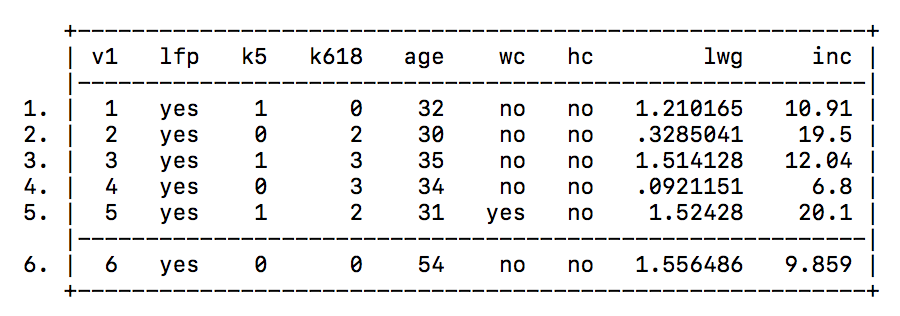

```r
*Importing data
import delimited https://vincentarelbundock.github.io/Rdatasets/csv/carData/Mroz.csv, clear
save mroz,replace
use mroz,clear
*List the first six rows
list if v1<=6
```

Then, we change all binary variables to be numeric, and we get a summary of the data. Our response is lfp and its mean is 0.57. The range of age is from 30 to 60.

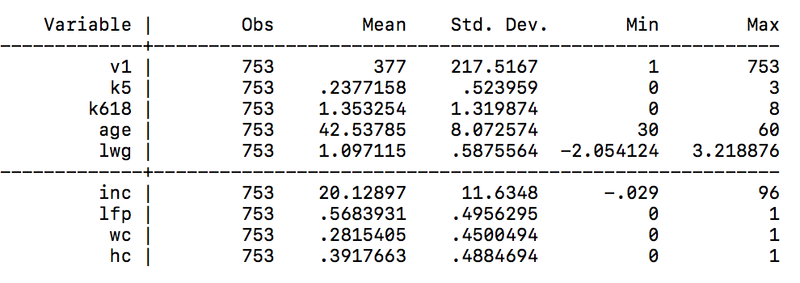

```r
*Change variables with values yes/no to 1/0
gen lfpart =1 if lfp == "yes"
replace lfpart =0 if lfp == "no"
gen wifec =1 if wc == "yes"
replace wifec =0 if wc == "no"
gen husbc =1 if hc == "yes"
replace husbc =0 if hc == "no"
drop lfp wc hc
rename lfpart lfp
rename wifec wc
rename husbc hc
*Get the summary of the data
summ
```

#### 2.Fitting model by Probit Regression

Now, we fit our data by probit regression. lfp is the response and the remaining variables are predictors. Looking at the p-values, all variables have high sigificance, except k618 and hc.

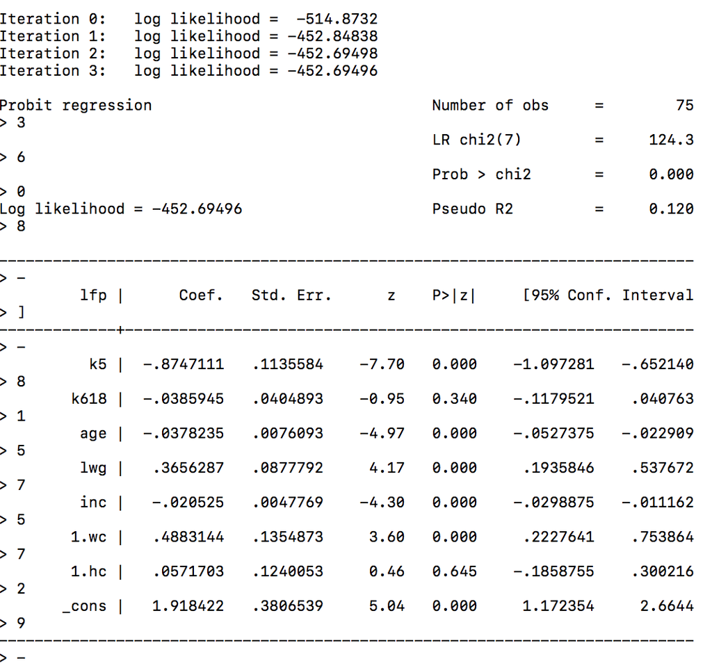

```r
*Fitting the data by probit regression
probit lfp k5 k618 age lwg inc i.wc i.hc
```

We get a summary of the probit prediction from the fitted model, we get that the smallest probability is  
0.005691 and the largest probability is 0.9745. The 50% percentile is 0.5782336, which is close to its mean shown above.

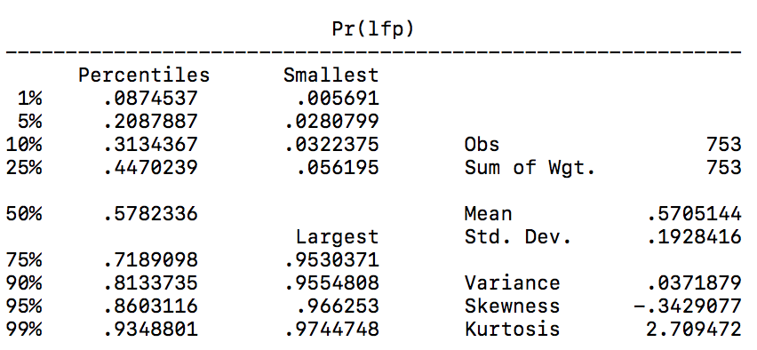

```r
*Predicting the probability of labor-force  participation
predict prob_lfp
summ prob_lfp, detail
```

#### 3.Marginal effect

Now, we predict the data for groups defined by levels of categorical variables.

##### Group by hc

First, we make a table of frequency counts of hc and lfp and we predict the lfp for two groups: hc=0 and hc=1, while keeping other variables at mean.

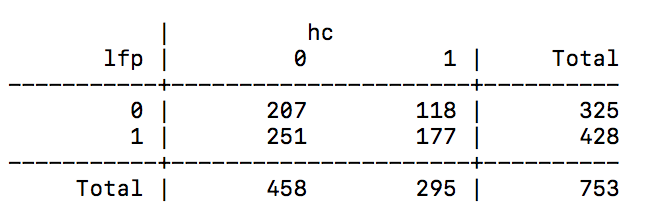

```r
tab lfp hc
```

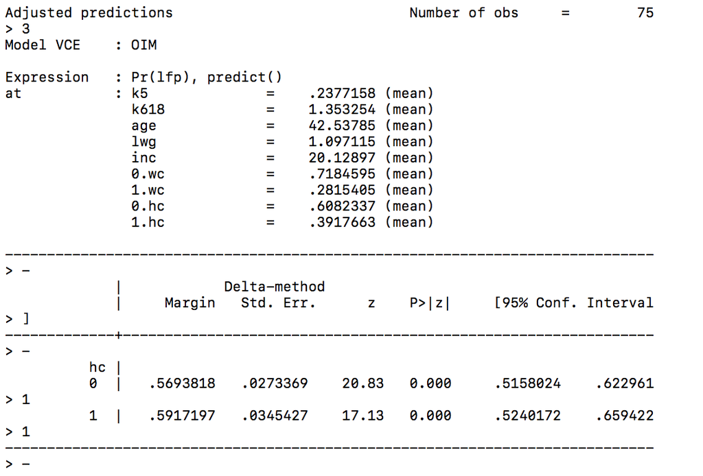

```r
*use margins for each level of hc
margins hc, atmeans
```

The marginal probability of hc=1 (husband has attained college) is 0.59 and it slightly higher than the marginal probability of hc=0 (husband has not attained college), which is 0.57. There is not an obivious differnce. It is reasonable because the p-value of hc is very high.

##### Group by wc

The table of frequency shows that when wc=0, the proportion of lfp is average, which is close to 0.5. However, when wc=1, the proportion of lfp=1 is much higher.

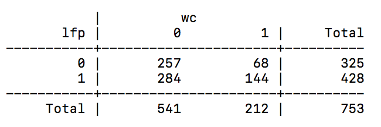

```r
tab lfp wc
```

We predict the lfp for two groups: wc=0 and wc=1, and we keep other variables at mean.

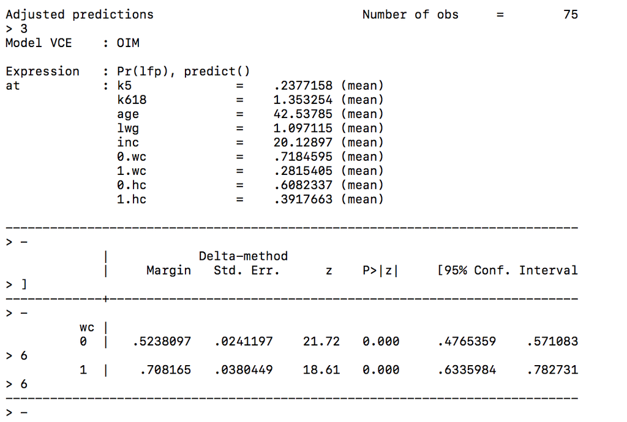

```r
*use margins for each level of wc
margins wc, atmeans
```

The result shows that the marginal probability is 0.71 when wc=1, and the marginal probability is 0.52 when wc=0. The probability of participating in the labor-force is higher when wife has attended college. We can say that wife’s college attendance is an important predictor.

We can go deeper on the predictor wc. We predict lfp for group by age and wc. Age is at every 10 years of age from 30 to 60. Since the output of marginal function is long, we make a plot to visualize the output and it is easier to interpert.

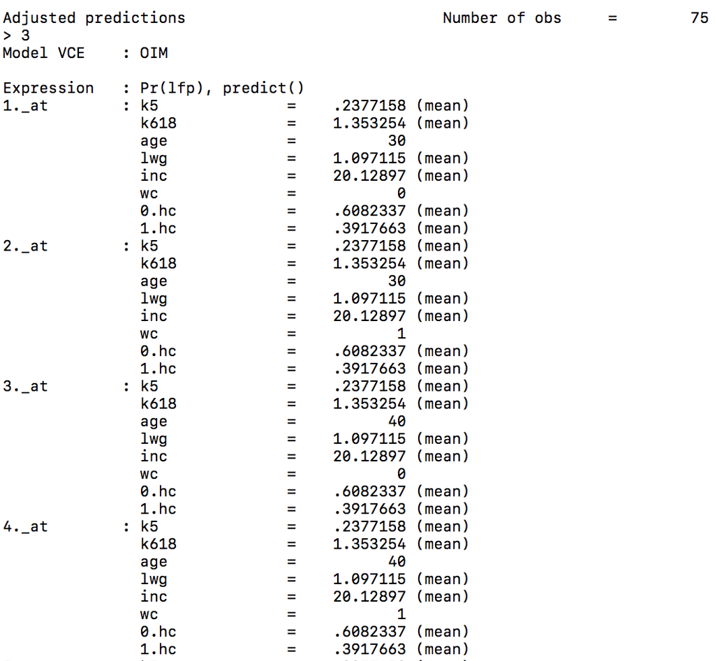

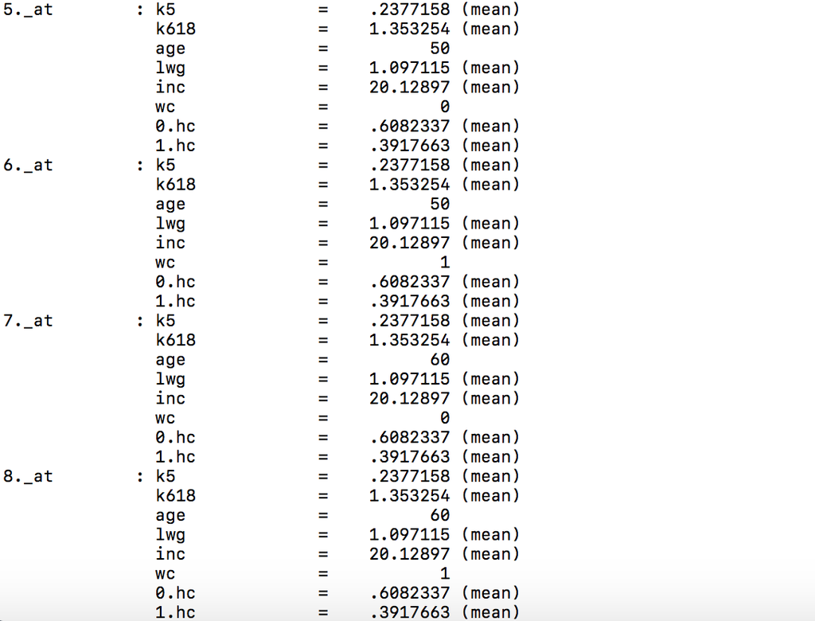

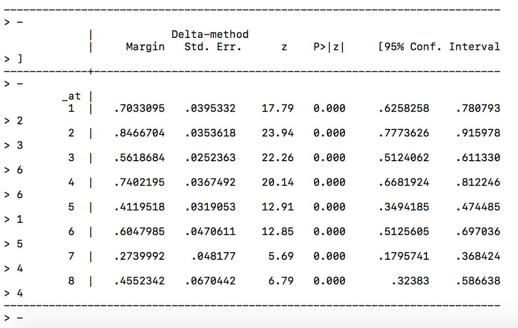

```r
*use margins for each level of wc and age
margins, at(age=(30(10)60) wc=(0 1)) atmeans vsquish
```

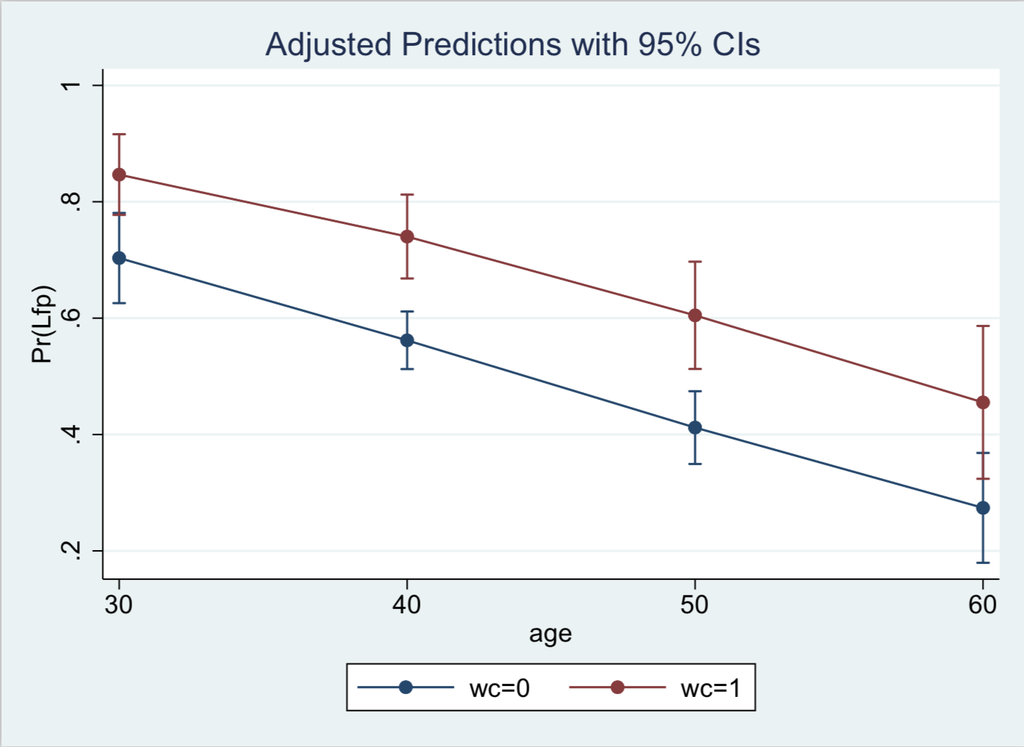

```r
marginsplot
```

Looking at the table, we can see the predicted probability of lfp is 0.7033095 if age is 30 and wc=0.It will increase to 0.8466704 if age is 30 and wc=1. From the marginal plot, we can conclude that when age is increasing, the probability is decreasing. Also, The probability of wc=1 is always higher than wc=0. At age 60, the variablity is the highest because the 95% confidence interval is the widest.

##### Group by k5

The table of frequency shows that the proportion of lfp is decreasing when k5 is increasing.

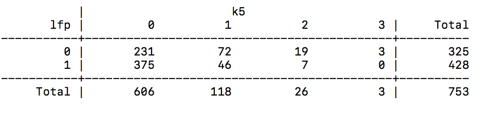

```r
tab lfp k5
```

We predict the lfp by k5= 0 1 2 3, and we keep other variables at mean. Also, we make a plot to visualize the data.

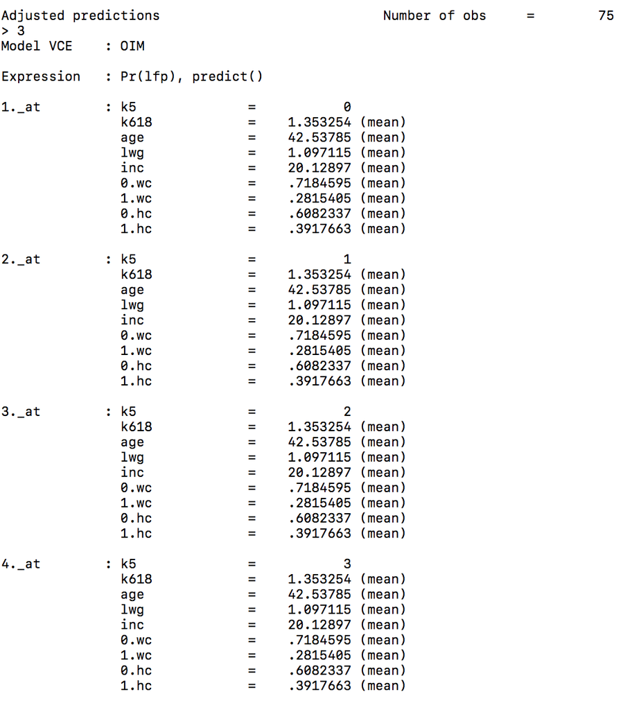

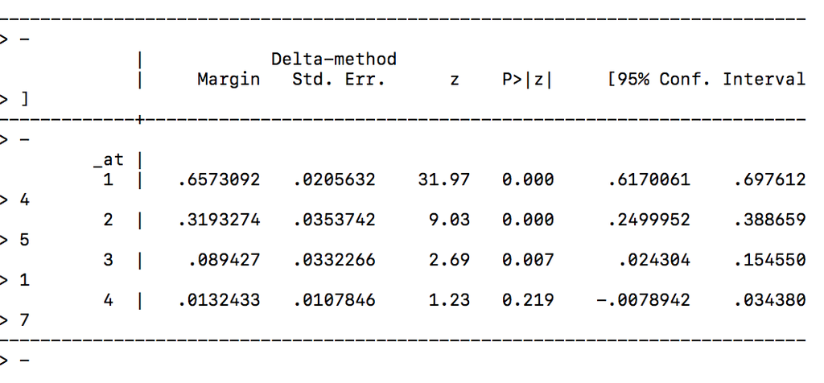

```r
*use margins for each level of k5
margins, at(k5=(0 1 2 3)) atmeans
```

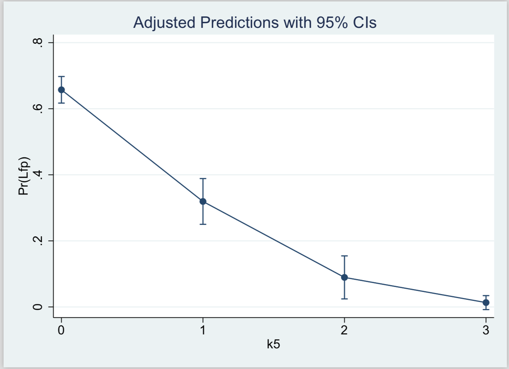

```r
marginsplot
```

The output shows that when women do not have any children 5 years old or younger, the probability of participating in the labor-force is 0.66 which is higher than the average. However, after they had children, the probability of participating in the labor-force is decreasing. Therefore, we can conclude that k5 is a significant predictor.

## Summary

[output not shown]

If we choose the coefficients from R, the equation is

$$probit(EY) = \Phi^{-1}(P_i[lfp=1]) = 1.918418-0.8747124\times k5
-0.03859517\times k618 -0.0378235\times age+ \\0.4883096\times wc +
0.0571716\times hc+ 0.3656348\times lwg+ -0.02052513\times inc$$

We do average marginal effects by the four languages. We also get the similar result. We predict the probability of labor-force participation by grouping a variable, while keeping other variables at mean. Grouping by hc,there is no obivious difference between probability,which confirmed that hc is not an significant indicator in our model. We also do the same procedure for wc, age and k5. We can conclude that these varibles have an effect on labor-force participation.

## References

- UCLA Probit Regression in R : https://stats.idre.ucla.edu/r/dae/probit-regression/
- Probit Regression in Python: http://www.statsmodels.org/0.6.1/examples/notebooks/generated/discrete_choice_overview.html https://www.statsmodels.org/dev/generated/statsmodels.discrete.discrete_model.Probit.html https://www.statsmodels.org/dev/examples/notebooks/generated/predict.html
- Probit Regression in STATA : https://stats.idre.ucla.edu/stata/dae/probit-regression/
- Probit Regression in SAS : https://communities.sas.com/t5/SAS-Programming/How-to-convert-Char-to-Numeric/td-p/322906 https://communities.sas.com/t5/SAS-Programming/How-to-convert-Char-to-Numeric/td-p/322906